# Lakers R Markdown Intro

David White

5/19/2021

This is my first markdown document. In it, I will analyze the dataset `lakers` from the `lubridate` package to produce a visualization of field goals attempted and made by the Los Angeles Lakers in their first game of the 2008 - 2009 NBA season, against the Portland Trailblazers.

### Loading Libraries and Data

First, let’s load our libraries and dataset. The data is found in the `lubridate` library. I will be using the `filter()` function, so I will need to load the `diplyr` library as well. Lastly, I will load the `ggplot2` library for my visualizations.

```r
library(lubridate)
library(dplyr)
```

```r
library(ggplot2)
data("lakers")
str(lakers)
```

```
## 'data.frame':    34624 obs. of  13 variables:
##  $ date     : int  20081028 20081028 20081028 20081028 20081028 20081028 20081028 20081028 20081028 20081028 ...
##  $ opponent : chr  "POR" "POR" "POR" "POR" ...
##  $ game_type: chr  "home" "home" "home" "home" ...
##  $ time     : chr  "12:00" "11:39" "11:37" "11:25" ...
##  $ period   : int  1 1 1 1 1 1 1 1 1 1 ...
##  $ etype    : chr  "jump ball" "shot" "rebound" "shot" ...
##  $ team     : chr  "OFF" "LAL" "LAL" "LAL" ...
##  $ player   : chr  "" "Pau Gasol" "Vladimir Radmanovic" "Derek Fisher" ...
##  $ result   : chr  "" "missed" "" "missed" ...
##  $ points   : int  0 0 0 0 0 2 0 1 0 2 ...
##  $ type     : chr  "" "hook" "off" "layup" ...
##  $ x        : int  NA 23 NA 25 NA 25 NA NA NA 36 ...
##  $ y        : int  NA 13 NA 6 NA 10 NA NA NA 21 ...
```

```r
head(lakers, 10)
```

```
##        date opponent game_type  time period      etype team              player
## 1  20081028      POR      home 12:00      1  jump ball  OFF
## 2  20081028      POR      home 11:39      1       shot  LAL           Pau Gasol
## 3  20081028      POR      home 11:37      1    rebound  LAL Vladimir Radmanovic
## 4  20081028      POR      home 11:25      1       shot  LAL        Derek Fisher
## 5  20081028      POR      home 11:23      1    rebound  LAL           Pau Gasol
## 6  20081028      POR      home 11:22      1       shot  LAL           Pau Gasol
## 7  20081028      POR      home 11:22      1       foul  POR           Greg Oden
## 8  20081028      POR      home 11:22      1 free throw  LAL           Pau Gasol
## 9  20081028      POR      home 11:00      1       foul  LAL Vladimir Radmanovic
## 10 20081028      POR      home 10:53      1       shot  POR   LaMarcus Aldridge
##    result points     type  x  y
## 1              0          NA NA
## 2  missed      0     hook 23 13
## 3              0      off NA NA
## 4  missed      0    layup 25  6
## 5              0      off NA NA
## 6    made      2     hook 25 10
## 7              0 shooting NA NA
## 8    made      1          NA NA
## 9              0 personal NA NA
## 10   made      2     jump 36 21
```

### Filtering Data Frames

I’m only interested in the first game of the season, which is denoted by the game’s date, October 28, 2008, or `20081028` in the `date` column. So I will use the `filter()` function from the `dplyr` library to create a new data frame.

```r
game1 <- filter(lakers, date == 20081028)
```

The original dataset includes information from both Laker players and Trailblazer players, so my new data frame does too. My analysis will be of Lakers only, so I will use `filter()` again to drop information about Portland players.

```r
game1_laker_players <- filter(game1, team == "LAL")
head(game1_laker_players, 10)
```

```
##        date opponent game_type  time period      etype team              player
## 1  20081028      POR      home 11:39      1       shot  LAL           Pau Gasol
## 2  20081028      POR      home 11:37      1    rebound  LAL Vladimir Radmanovic
## 3  20081028      POR      home 11:25      1       shot  LAL        Derek Fisher
## 4  20081028      POR      home 11:23      1    rebound  LAL           Pau Gasol
## 5  20081028      POR      home 11:22      1       shot  LAL           Pau Gasol
## 6  20081028      POR      home 11:22      1 free throw  LAL           Pau Gasol
## 7  20081028      POR      home 11:00      1       foul  LAL Vladimir Radmanovic
## 8  20081028      POR      home 10:45      1       shot  LAL        Derek Fisher
## 9  20081028      POR      home 10:31      1    rebound  LAL         Kobe Bryant
## 10 20081028      POR      home 10:21      1       shot  LAL           Pau Gasol
##    result points        type  x  y
## 1  missed      0        hook 23 13
## 2              0         off NA NA
## 3  missed      0       layup 25  6
## 4              0         off NA NA
## 5    made      2        hook 25 10
## 6    made      1             NA NA
## 7              0    personal NA NA
## 8    made      2 pullup jump 30 21
## 9              0         def NA NA
## 10   made      2        jump 15 17
```

As you can see, now the rows with `POR` values in the `team` column are gone.

I’m only interested in analyzing shots from the field – no free throws will be used in my analysis. I therefore will employ the `filter()` function once again to accomplish this goal.

```r
game1_laker_fgs <- filter(game1_laker_players, etype == "shot")
head(game1_laker_fgs)
```

```
##       date opponent game_type  time period etype team       player result
## 1 20081028      POR      home 11:39      1  shot  LAL    Pau Gasol missed
## 2 20081028      POR      home 11:25      1  shot  LAL Derek Fisher missed
## 3 20081028      POR      home 11:22      1  shot  LAL    Pau Gasol   made
## 4 20081028      POR      home 10:45      1  shot  LAL Derek Fisher   made
## 5 20081028      POR      home 10:21      1  shot  LAL    Pau Gasol   made
## 6 20081028      POR      home 09:50      1  shot  LAL Andrew Bynum missed
##   points        type  x  y
## 1      0        hook 23 13
## 2      0       layup 25  6
## 3      2        hook 25 10
## 4      2 pullup jump 30 21
## 5      2        jump 15 17
## 6      0        jump 21 10
```

I have the data I want. Now I can create a visualization of that data using `ggplot2`.

### Visualizations with ggplot2

I want to compare made field goals and missed field goals for each player. Doing so will give me a superficial idea of each player’s efficiency in the game.

Using `ggplot`’s `geom_bar()` and `facet_wrap()` functions, I can build the visualization I want. I will show makes and misses on the x-axis, and the count of each on the y-axis. I will divide the plots using the `player` column.

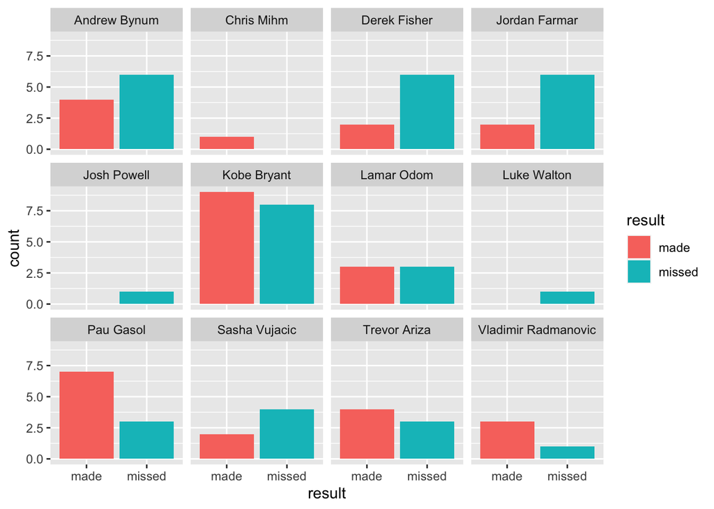

```r
ggplot(game1_laker_fgs) +
  geom_bar(aes(x = result, fill = result)) +
  facet_wrap(~player)
```

This visualization looks great. I can very quickly see that Kobe Bryant and Pau Gasol were the highest volume shooters on the team, and that Gasol in particular was very efficient. I also note that Luke Walton and Derek Fisher struggled mightily, which confirms my assumptions about their abilities.

I want to tweak my visualization to get it just right. I will use my colors more intentionally, with blue being a made shot and red being a miss.[^1] I can do this by creating a vector of those colors. Organizing the colors this way will also eliminate the need for a legend, so I can get rid of it. Lastly, I want the players’ names at the bottom of each plot instead of the top, since that would improve readability. I will change the code accordingly.

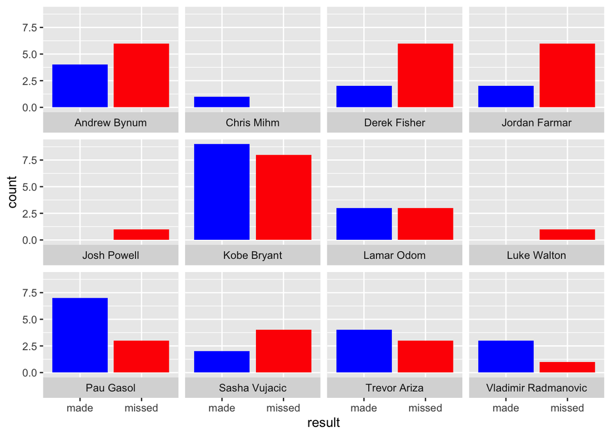

```r
ggplot(game1_laker_fgs) +
  geom_bar(aes(x = result, fill = result), show.legend = FALSE) +
  facet_wrap(~player, strip.position = "bottom") +
  scale_fill_manual(values = c("blue", "red"))
```

That’s better, but the colors are a little too bright for my taste. I will make them a little paler using values from the `ggplot2` [predefined color name list](http://sape.inf.usi.ch/quick-reference/ggplot2/colour).

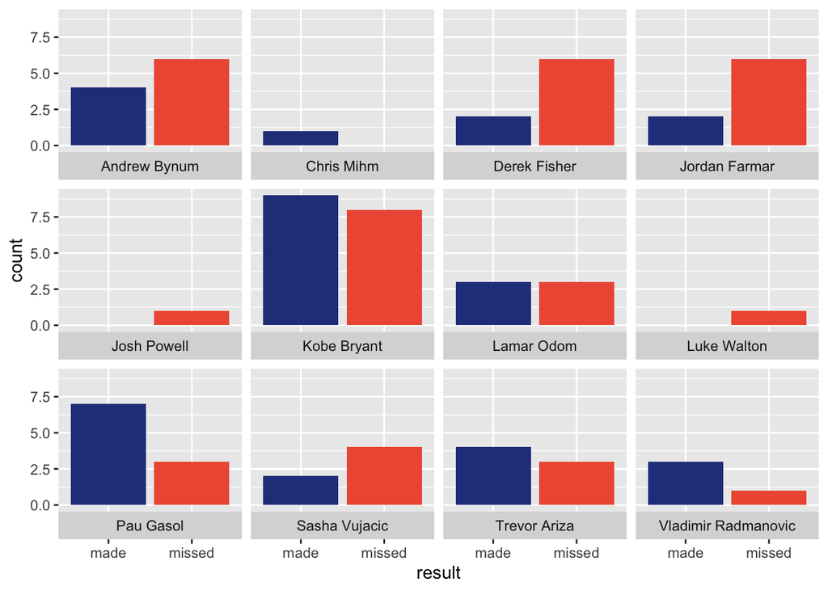

```r
ggplot(game1_laker_fgs) +
  geom_bar(aes(x = result, fill = result), show.legend = FALSE) +
  facet_wrap(~player, strip.position = "bottom") +
  scale_fill_manual(values = c("royalblue4", "tomato2"))
```

That’s a little easier on the eyes.

To put some finishing touches on the visualization, I will add a title and subtitle using labs(), apply a minimalist theme, and remove the labels from the x and y axes.

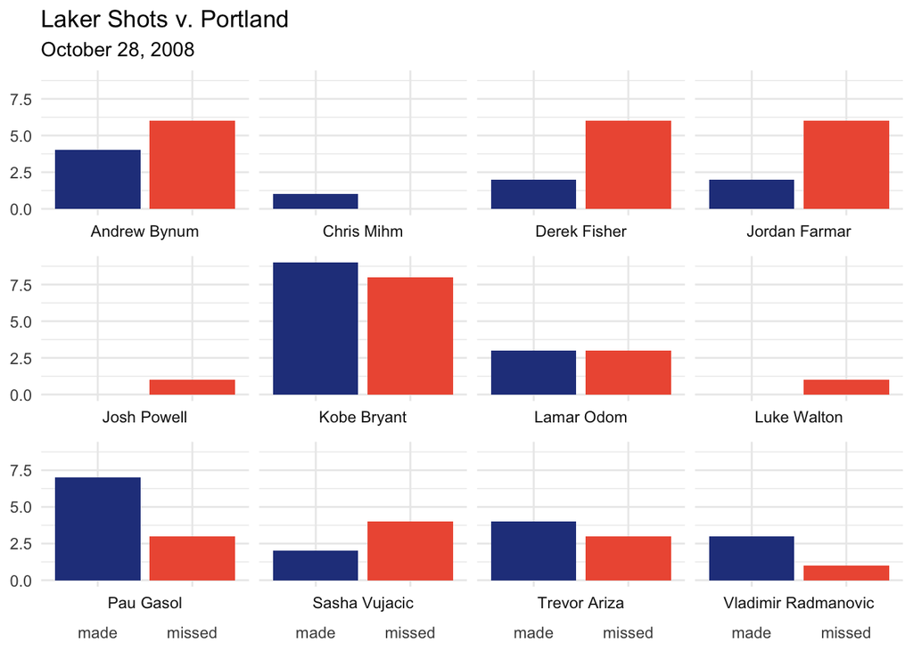

```r
ggplot(game1_laker_fgs) +
  geom_bar(aes(x = result, fill = result), show.legend = FALSE) +
  facet_wrap(~player, strip.position = "bottom") +
  scale_fill_manual(values = c("royalblue4", "tomato2")) +
  labs(x = NULL, y = NULL, title = "Laker Shots v. Portland", subtitle = "October 28, 2008") +
  theme_minimal()
```

Things look good!

And then I notice something peculiar. The y-axis measures number of shots taken. This measurement is discrete – you can’t take half of a shot, after all. But the y-axis appears to be measuring shots as a continuous value, as it has tick marks every 2.5 shots. I will use `scale_y_continuous()` and `seq()` to fix this issue. I will set the max of the y-axis at 10, since no player has makes or misses that exceed that value, and a step value of 2.

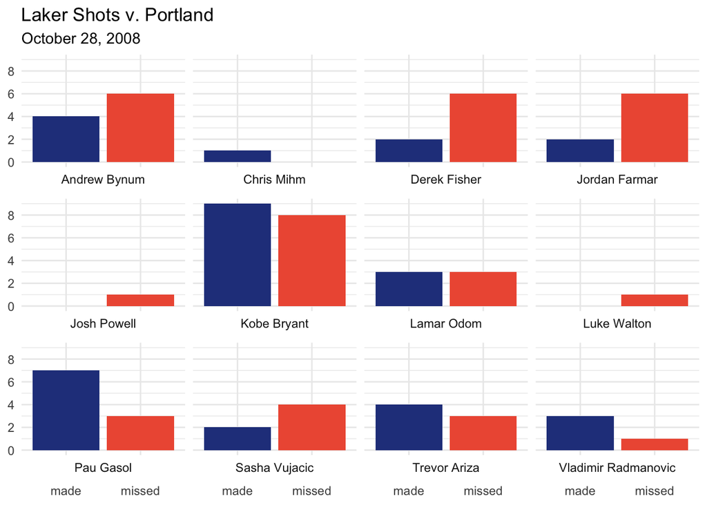

```r
ggplot(game1_laker_fgs) +
  geom_bar(aes(x = result, fill = result), show.legend = FALSE) +
  facet_wrap(~player, strip.position = "bottom") +
  scale_fill_manual(values = c("royalblue4", "tomato2")) +
  labs(x = NULL, y = NULL, title = "Laker Shots v. Portland", subtitle = "October 28, 2008") +
  theme_minimal() +
  scale_y_continuous(breaks = seq(0, 10, 2))
```

Now the y-axis looks correct. My visualization, as well as my first R Markdown file, are now complete.

[^1]: I chose not to use the Lakers’ color scheme (purple and gold) for this visualization because I did not feel those colors juxtapose themselves as well as blue and red.